# 基礎 R 語法寫作示範

陳紹慶

2021/7/6

> 講義範例來自R基本實作秘訣速查表，搭配參考Rstudio視覺介面以及Rmarkdown秘訣速查表。

## 預先載入套件

一份Rmarkdown文件經常使用非內建套件(package)的函式(function)與資料，為了能在文件內正常使用這些套件的函式，建議方式是在R markdown的第一個chunk載入。這段文字之後的`setup` chunk，渲染後(Knit)不會在輸出文件顯示chunk內的程式碼，你可以從源始Rmarkdown檔檢視安裝及載入套件的程式碼。

## 使用內建套件

載入內建資料：“iris”是經典生物統計資料集，常用於各式統計方法及程式測試。資料集介紹請見維基百科條目：[安德森鳶尾花卉數據集](https://zh.wikipedia.org/wiki/%E5%AE%89%E5%BE%B7%E6%A3%AE%E9%B8%A2%E5%B0%BE%E8%8A%B1%E5%8D%89%E6%95%B0%E6%8D%AE%E9%9B%86)。

```r
data(iris)
head(iris)
```

```
##   Sepal.Length Sepal.Width Petal.Length Petal.Width Species
## 1          5.1         3.5          1.4         0.2  setosa
## 2          4.9         3.0          1.4         0.2  setosa
## 3          4.7         3.2          1.3         0.2  setosa
## 4          4.6         3.1          1.5         0.2  setosa
## 5          5.0         3.6          1.4         0.2  setosa
## 6          5.4         3.9          1.7         0.4  setosa
```

iris 資料有五個變項。

### 查詢使用說明

在console視窗輸入以下任何查詢指令，可開啟函式或套件的說明文件。

```
?mean  ## 取得函式的說明文件
help.search('weightedmean')  ## 以關鍵詞查詢有weightedmean函式的套件說明文件
help(package ='dplyr')  ## 關鍵詞查詢說明文件
```

### 查詢資料物件性質

資料與函式在R環境通稱“物件”(Objects)，物件有兩種性質：形態(class)與資料結構(structure)。R環境設資料物件形態有數值(value)、向量(vector)、矩陣(matrix)、資料框架(data frame)、以及列表(List)。每種型態都有指定的資料結構，依照資料結構建立的資料物件，才能輸入函式，執行計算、資料整頓等工作。

```r
class(iris) ## 顯示物件型態
```

```
## [1] "data.frame"
```

```r
str(iris)   ## 顯示物作型態與資料結果
```

```
## 'data.frame':    150 obs. of  5 variables:
##  $ Sepal.Length: num  5.1 4.9 4.7 4.6 5 5.4 4.6 5 4.4 4.9 ...
##  $ Sepal.Width : num  3.5 3 3.2 3.1 3.6 3.9 3.4 3.4 2.9 3.1 ...
##  $ Petal.Length: num  1.4 1.4 1.3 1.5 1.4 1.7 1.4 1.5 1.4 1.5 ...
##  $ Petal.Width : num  0.2 0.2 0.2 0.2 0.2 0.4 0.3 0.2 0.2 0.1 ...
##  $ Species     : Factor w/ 3 levels "setosa","versicolor",..: 1 1 1 1 1 1 1 1 1 1 ...
```

## 工作目錄

- 工作目錄是R環境輸入及輸出檔案的資料夾路徑。有三種方法可確認現在的工作目錄。
1. 在console視窗執行`getwd()`。
2. 在Rstudio切換Files視窗，點擊右上角Rstudio logo。

[figure not shown]

3. 在Rmarkdown文件內編輯的程式碼，工作目錄是文件存檔的資料夾路徑。
- 若非必要，不建議更改工作目錄。若要更改可使用`setwd()`設定其他資料夾路徑。

## 存取資料

資料檔可存放於工作目錄之外的資料夾路徑，未處理的資料建議以csv格式存檔。

### 讀取資料檔

如果要使用之前儲存的映像檔(RData)，建議在文件第一個chunk `setup`執行匯入`load()`。

讀取前確認資料檔第一列(row)為欄位標題，才能獲得如範例的執行效果。 以五大人格測驗資料為例：

```r
# 讀取格式化分欄的純文字檔
big5_01 <- read.table(file = "../data/5factor.txt", header = TRUE)
head(big5_01)
```

```
##   subj_id        O   C        E        A     N
## 1     S01 4.428571 4.5 3.333333 5.142857 1.625
## 2     S02 5.714286 2.9 3.222222 3.000000 2.625
## 3     S03 5.142857 2.8 6.000000 3.571429 2.500
## 4     S04 3.142857 5.2 1.333333 1.571429 3.125
## 5     S05 5.428571 4.4 2.444444 4.714286 1.625
## 6     S06 4.428571 2.2 3.111111 4.571429 4.000
```

```r
# 讀取逗號分欄的純文字檔
big5_02 <- read.csv(file = "../data/5factor.csv")
head(big5_02)
```

```
##   subj_id        O   C        E        A     N
## 1     S01 4.428571 4.5 3.333333 5.142857 1.625
## 2     S02 5.714286 2.9 3.222222 3.000000 2.625
## 3     S03 5.142857 2.8 6.000000 3.571429 2.500
## 4     S04 3.142857 5.2 1.333333 1.571429 3.125
## 5     S05 5.428571 4.4 2.444444 4.714286 1.625
## 6     S06 4.428571 2.2 3.111111 4.571429 4.000
```

### 寫入資料檔

存放資料檔格式以有分欄的純文字檔優先考慮，有其他格式或需儲存檔案太多，再考慮以映像檔(RData)儲存。

```r
## 建議增加參數row.names = FALSE
## 寫入格式化分欄的純文字檔
write.table(head(big5_01), file = "big5_head.txt",row.names = FALSE)
## 寫入逗號分欄的純文字檔
write.csv(head(big5_02), file = "big5_head.csv",row.names = FALSE)
```

## 檢視及建立物件

- 執行大量程式碼將在R環境記憶體留存物件，改寫程式碼過程經常要檢視已存物件。檢視物件有兩種方法。
1. 在console視窗執行`ls()`，列印已存物件名稱。
2. 在Rstudio切換Environment視窗，查看已存物件清單。
- 移除已存物件的方法：
1. 移除指定物件：在console視窗，或程式碼腳本，執行`rm(x)`(x代表任何已存物件)。
2. 移除全部物件：在console視窗，或程式碼腳本，執行`rm(list = ls())`。
3. 在Rstudio主選單選擇“Session -> Restart R and Clear Output”，清除所有已存物件及已載入套件。

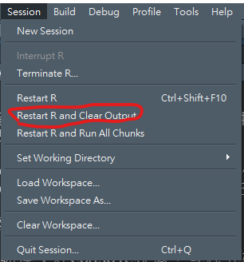

- 建立物件：使用指派運算子`<-`指派物件內容。R自動判斷運算子右方的資料結構，賦予物件型態。

```r
## 指派數值
a <- "apple"
## 建立函式
square <- function(x){
  squared = x*x
  return(squared)
}
## 檢視函式執行效果
square(7)
```

```
## [1] 49
```